# Dada2_report

Ramón Gallego

1/9/2018

## Dada2 report

You have successfully split your libraries into a pair (or two) of fastq files per sample. Now let’s import the output of demultiplex_both_fastq.sh

First load the packages. And let’s update the parameters we need

```
## # A tibble: 6 x 3
##   Full_Id                           fastq_header Sample
##   <chr>                             <chr>        <chr>
## 1 ID1=Lib_C;ID2A=TCGCAT;ID2B=ATGCGA Lib_C_TCGCAT PG_Al_1_May_A_r3
## 2 ID1=Lib_B;ID2A=TCGCAT;ID2B=ATGCGA Lib_B_TCGCAT PG_Al_3_May_A_r3
## 3 ID1=Lib_E;ID2A=ACAGCA;ID2B=TGCTGT Lib_E_ACAGCA PG_Al_6_May_A_r3
## 4 ID1=Lib_F;ID2A=GCGCTC;ID2B=GAGCGC Lib_F_GCGCTC PG_Al_10_May_A_r3
## 5 ID1=Lib_D;ID2A=TCGCAT;ID2B=ATGCGA Lib_D_TCGCAT PG_Al_15_May_A_r3
## 6 ID1=Lib_B;ID2A=ACATGT;ID2B=ACATGT Lib_B_ACATGT PG_Al_1_Aug_A_r3
```

```
## [1] "/Users/ramongallego/GoogleDrive/Raw_data/Halo/EJP_ROUND3/Lib-B-EJP-ROUND3_S2_L001_R1_001.fastq"
```

Firstly, we’ll find the patterns that separate our Fwd, Rev, .1 and .2 files. look at the quality of the .1 and .2 reads

```r
F1s <- sort(list.files(path1, pattern="_Fwd.1.fastq", full.names = TRUE))
F2s <- sort(list.files(path1, pattern="_Fwd.2.fastq", full.names = TRUE))
R1s <- sort(list.files(path1, pattern="_Rev.1.fastq", full.names = TRUE))
R2s <- sort(list.files(path1, pattern="_Rev.2.fastq", full.names = TRUE))

# Extract sample names, assuming filenames have format: SAMPLENAME_XXX.fastq
sample.names <- str_replace(basename(F1s), "_Fwd.1.fastq","")

#Now use only those that reflect a real sample

good.sample.names<-sample.names[sample.names %in% sample.map$fastq_header]
# Introduce here the biological counterpart of the fastq file

real.sample.name <- sample.map[,3][match(good.sample.names,sample.map$fastq_header),1]

# Now subset the number of files to be looked at

F1sgood<-F1s[sample.names %in% sample.map$fastq_header]
F2sgood<-F2s[sample.names %in% sample.map$fastq_header]
R1sgood<-R1s[sample.names %in% sample.map$fastq_header]
R2sgood<-R2s[sample.names %in% sample.map$fastq_header]
```

A nice idea is to plot the Quality of the F1 reads

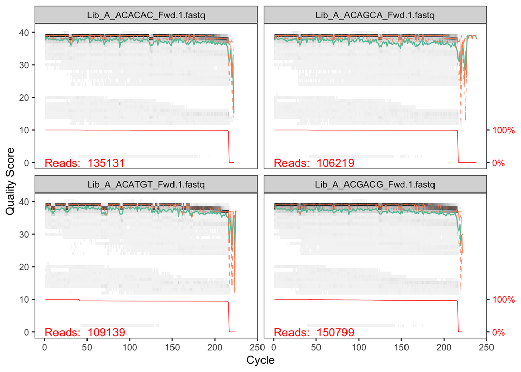

The quality should be similar to that of the Reverse .1 reads

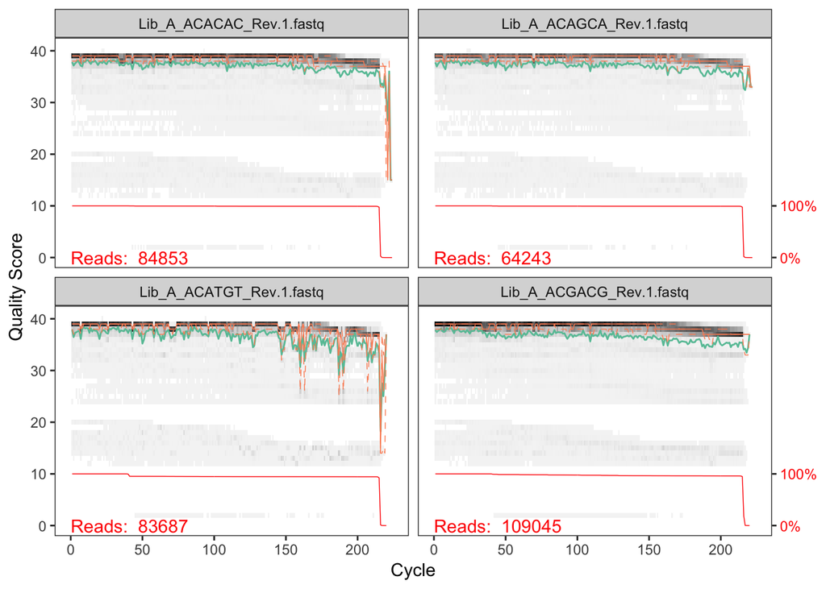

On the other hand, the quality of the .2 reads should decrease earlier

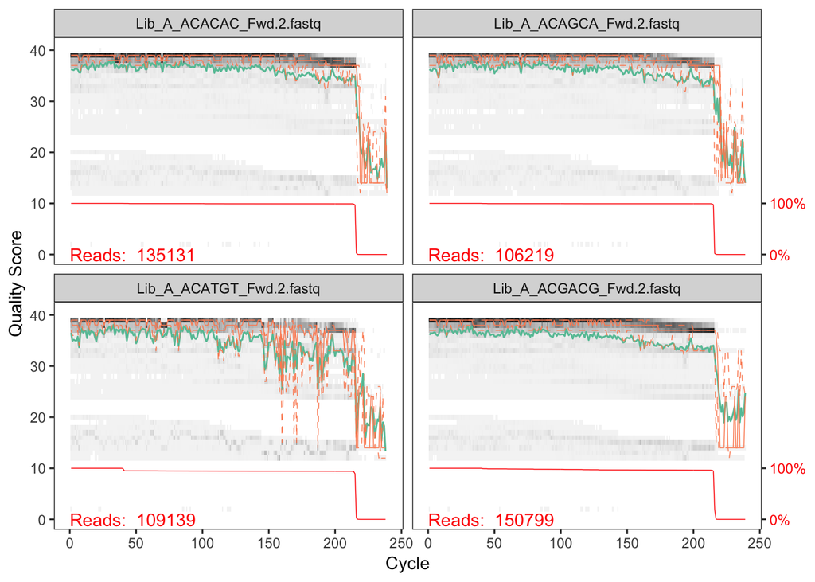

## Now start with the trimming of each read based on the quality we just plotted

```r
filt_path <- file.path(params$folder, "/filtered") # Place filtered files in filtered/ subdirectory
filtF1s <- file.path(filt_path, paste0(good.sample.names, "_F1_filt.fastq.gz"))
filtF2s <- file.path(filt_path, paste0(good.sample.names, "_F2_filt.fastq.gz"))
out_Fs <- filterAndTrim(F1sgood, filtF1s, F2sgood, filtF2s, truncLen=c(200,200),
                      maxN=0, maxEE=c(2,2), truncQ=2, rm.phix=TRUE,
                      compress=TRUE, multithread=TRUE) # On Windows set multithread=FALSE
```

```
## Creating output directory: /Users/ramongallego/fastqs_demultiplexed_for_DADA2/demultiplexed_20190214_1600//filtered
```

```r
filtR1s <- file.path(filt_path, paste0(good.sample.names, "_R1_filt.fastq.gz"))
filtR2s <- file.path(filt_path, paste0(good.sample.names, "_R2_filt.fastq.gz"))
out_Rs <- filterAndTrim(R1sgood, filtR1s, R2sgood, filtR2s, truncLen=c(200,200),
                      maxN=0, maxEE=c(2,2), truncQ=2, rm.phix=TRUE,
                      compress=TRUE, multithread=TRUE)
```

```r
out_Fs_tibble<-tibble(file=dimnames(out_Fs)[[1]], reads.out=out_Fs[,2])
out_Rs_tibble<-tibble(file=dimnames(out_Rs)[[1]], reads.out=out_Rs[,2])
out_Fs_tibble
```

```
## # A tibble: 63 x 2
##    file                     reads.out
##    <chr>                        <dbl>
##  1 Lib_A_ACACAC_Fwd.1.fastq    126041
##  2 Lib_A_ACAGCA_Fwd.1.fastq     96016
##  3 Lib_A_ACATGT_Fwd.1.fastq     93100
##  4 Lib_A_ACGACG_Fwd.1.fastq    133366
##  5 Lib_A_ATATCG_Fwd.1.fastq    120337
##  6 Lib_A_CTCGCA_Fwd.1.fastq    149813
##  7 Lib_A_GCGCTC_Fwd.1.fastq    127759
##  8 Lib_A_GTCTCT_Fwd.1.fastq     88378
##  9 Lib_A_TCGCAT_Fwd.1.fastq    109408
## 10 Lib_B_ACACAC_Fwd.1.fastq    183376
## # … with 53 more rows
```

Now the first crucial step: learning the error rates that would be different for fwd and rev reads

```r
errF1 <- learnErrors(filtF1s, multithread=TRUE,verbose = 0)
errF2 <- learnErrors(filtF2s, multithread=TRUE,verbose = 0)
errR1 <- learnErrors(filtR1s, multithread=TRUE,verbose = 0)
errR2 <- learnErrors(filtR2s, multithread=TRUE,verbose = 0)

# Write errors to csv to see if they matter at all
tosave <- list(errF1, errF2, errR1, errR2)

saveRDS(tosave, file = "all.errors.rds")
```

Which we can plot now to see the error rates between transitions of each pair of nt

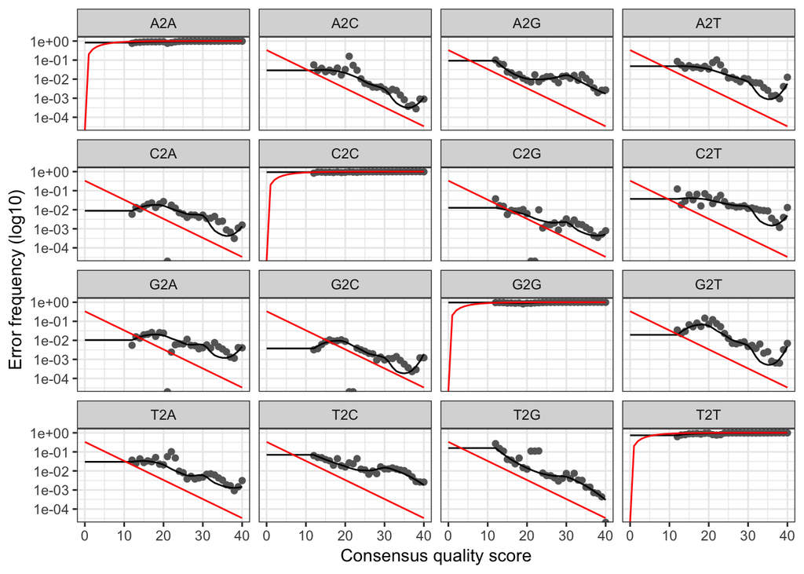

```r
plotErrors(errF1, nominalQ = T)
```

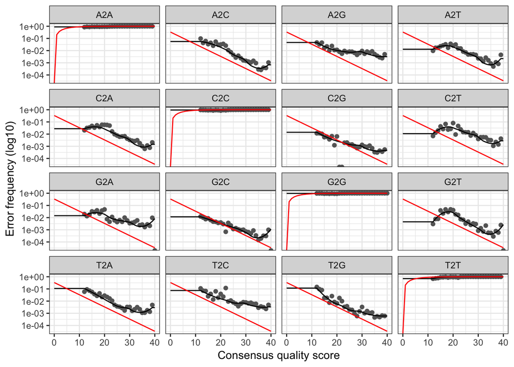

```r
plotErrors(errF2, nominalQ = T)
```

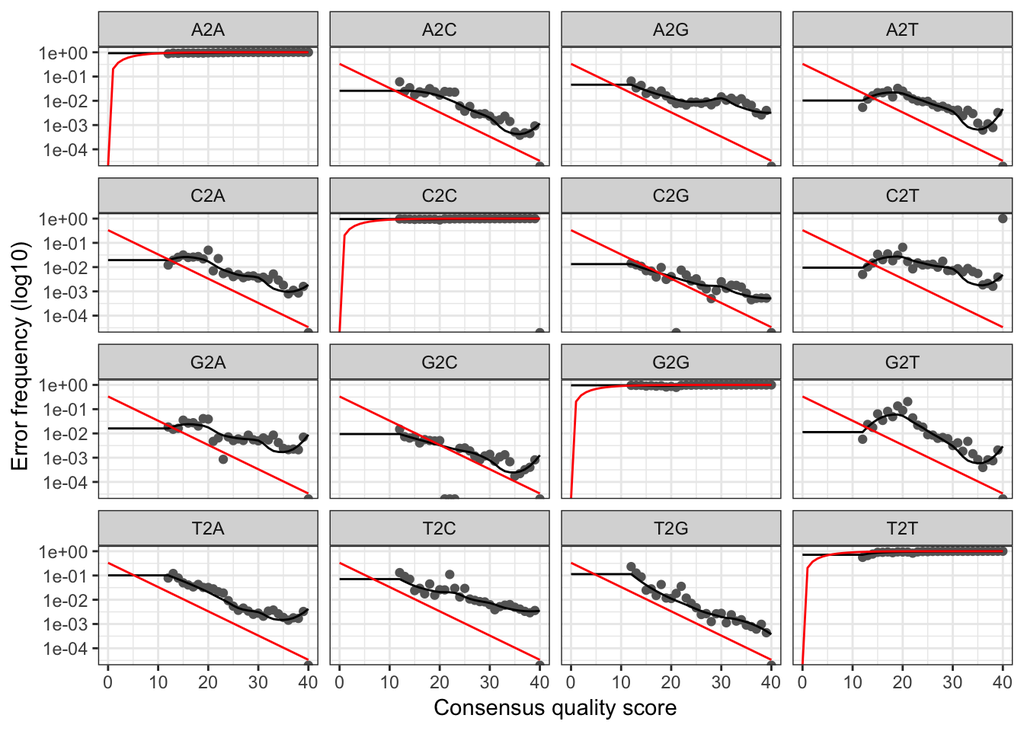

```r
plotErrors(errR1, nominalQ = T)
```

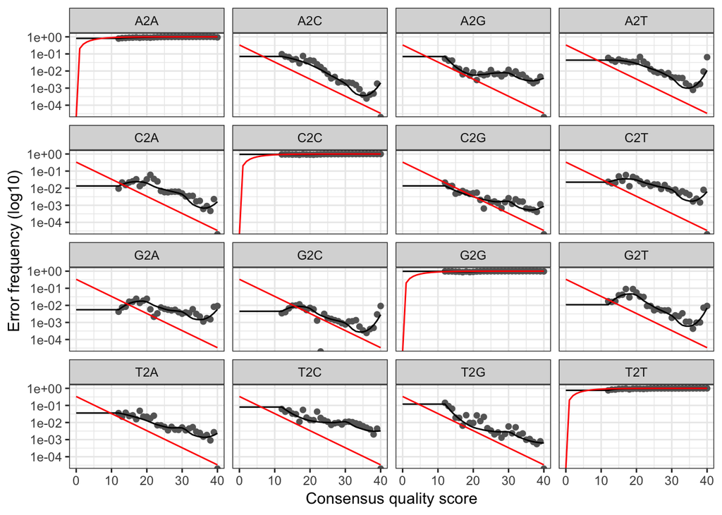

```r
plotErrors(errR2, nominalQ = T)
```

## Now go to the dereplication step

## And finally an inference of the sample composition

```r
dadaF1s <- dada(derepF1s, err = errF1, multithread = TRUE)
```

```
## Sample 1 - 126041 reads in 32856 unique sequences.
## Sample 2 - 96016 reads in 19899 unique sequences.
## Sample 3 - 93100 reads in 11203 unique sequences.
## Sample 4 - 133366 reads in 43735 unique sequences.
## Sample 5 - 120337 reads in 29700 unique sequences.
## Sample 6 - 149813 reads in 35386 unique sequences.
## Sample 7 - 127759 reads in 33597 unique sequences.
## Sample 8 - 88378 reads in 23105 unique sequences.
## Sample 9 - 109408 reads in 32233 unique sequences.
## Sample 10 - 183376 reads in 45742 unique sequences.
## Sample 11 - 91846 reads in 33569 unique sequences.
## Sample 12 - 101706 reads in 27714 unique sequences.
## Sample 13 - 143200 reads in 33728 unique sequences.
## Sample 14 - 78992 reads in 9653 unique sequences.
## Sample 15 - 131722 reads in 43140 unique sequences.
## Sample 16 - 75681 reads in 15566 unique sequences.
## Sample 17 - 103456 reads in 27912 unique sequences.
## Sample 18 - 93864 reads in 32948 unique sequences.
## Sample 19 - 78896 reads in 22111 unique sequences.
## Sample 20 - 95269 reads in 25938 unique sequences.
## Sample 21 - 107890 reads in 26214 unique sequences.
## Sample 22 - 85035 reads in 24368 unique sequences.
## Sample 23 - 90510 reads in 24038 unique sequences.
## Sample 24 - 132856 reads in 44128 unique sequences.
## Sample 25 - 106698 reads in 26779 unique sequences.
## Sample 26 - 177623 reads in 39680 unique sequences.
## Sample 27 - 118229 reads in 44571 unique sequences.
## Sample 28 - 89832 reads in 26094 unique sequences.
## Sample 29 - 102468 reads in 30250 unique sequences.
## Sample 30 - 96119 reads in 26923 unique sequences.
## Sample 31 - 129925 reads in 31221 unique sequences.
## Sample 32 - 106583 reads in 27320 unique sequences.
## Sample 33 - 106846 reads in 38637 unique sequences.
## Sample 34 - 133846 reads in 33458 unique sequences.
## Sample 35 - 145498 reads in 42568 unique sequences.
## Sample 36 - 88370 reads in 33647 unique sequences.
## Sample 37 - 182186 reads in 40649 unique sequences.
## Sample 38 - 65868 reads in 24923 unique sequences.
## Sample 39 - 109437 reads in 24148 unique sequences.
## Sample 40 - 72601 reads in 18599 unique sequences.
```

[output cut: 8 more lines]

```
## Sample 49 - 105469 reads in 22339 unique sequences.
## Sample 50 - 118281 reads in 28844 unique sequences.
## Sample 51 - 98491 reads in 25132 unique sequences.
## Sample 52 - 104757 reads in 37585 unique sequences.
## Sample 53 - 123711 reads in 30988 unique sequences.
## Sample 54 - 100620 reads in 33154 unique sequences.
## Sample 55 - 57240 reads in 17565 unique sequences.
## Sample 56 - 97205 reads in 26384 unique sequences.
## Sample 57 - 106476 reads in 27179 unique sequences.
## Sample 58 - 103325 reads in 21728 unique sequences.
## Sample 59 - 84586 reads in 22782 unique sequences.
## Sample 60 - 137361 reads in 41335 unique sequences.
## Sample 61 - 123059 reads in 44563 unique sequences.
## Sample 62 - 102065 reads in 36001 unique sequences.
## Sample 63 - 75435 reads in 23676 unique sequences.
```

```r
dadaF2s <- dada(derepF2s, err = errF2, multithread = TRUE)
```

```
## Sample 1 - 126041 reads in 38083 unique sequences.
## Sample 2 - 96016 reads in 24638 unique sequences.
## Sample 3 - 93100 reads in 21940 unique sequences.
## Sample 4 - 133366 reads in 54045 unique sequences.
## Sample 5 - 120337 reads in 35711 unique sequences.
## Sample 6 - 149813 reads in 43006 unique sequences.
## Sample 7 - 127759 reads in 41077 unique sequences.
## Sample 8 - 88378 reads in 25578 unique sequences.
## Sample 9 - 109408 reads in 38762 unique sequences.
## Sample 10 - 183376 reads in 55746 unique sequences.
## Sample 11 - 91846 reads in 38347 unique sequences.
## Sample 12 - 101706 reads in 33079 unique sequences.
## Sample 13 - 143200 reads in 41618 unique sequences.
## Sample 14 - 78992 reads in 19767 unique sequences.
## Sample 15 - 131722 reads in 54379 unique sequences.
## Sample 16 - 75681 reads in 19083 unique sequences.
## Sample 17 - 103456 reads in 32854 unique sequences.
## Sample 18 - 93864 reads in 40269 unique sequences.
## Sample 19 - 78896 reads in 26150 unique sequences.
## Sample 20 - 95269 reads in 29921 unique sequences.
## Sample 21 - 107890 reads in 32179 unique sequences.
## Sample 22 - 85035 reads in 30234 unique sequences.
## Sample 23 - 90510 reads in 30223 unique sequences.
## Sample 24 - 132856 reads in 54951 unique sequences.
## Sample 25 - 106698 reads in 33179 unique sequences.
## Sample 26 - 177623 reads in 48916 unique sequences.
## Sample 27 - 118229 reads in 56274 unique sequences.
## Sample 28 - 89832 reads in 30515 unique sequences.
## Sample 29 - 102468 reads in 36072 unique sequences.
## Sample 30 - 96119 reads in 32950 unique sequences.
## Sample 31 - 129925 reads in 37162 unique sequences.
## Sample 32 - 106583 reads in 31079 unique sequences.
## Sample 33 - 106846 reads in 46646 unique sequences.
## Sample 34 - 133846 reads in 42929 unique sequences.
## Sample 35 - 145498 reads in 52865 unique sequences.
## Sample 36 - 88370 reads in 39256 unique sequences.
## Sample 37 - 182186 reads in 46754 unique sequences.
## Sample 38 - 65868 reads in 29764 unique sequences.
## Sample 39 - 109437 reads in 32023 unique sequences.
## Sample 40 - 72601 reads in 21593 unique sequences.
```

[output cut: 8 more lines]

```
## Sample 49 - 105469 reads in 26861 unique sequences.
## Sample 50 - 118281 reads in 34674 unique sequences.
## Sample 51 - 98491 reads in 29585 unique sequences.
## Sample 52 - 104757 reads in 46963 unique sequences.
## Sample 53 - 123711 reads in 36720 unique sequences.
## Sample 54 - 100620 reads in 38908 unique sequences.
## Sample 55 - 57240 reads in 20398 unique sequences.
## Sample 56 - 97205 reads in 31359 unique sequences.
## Sample 57 - 106476 reads in 33222 unique sequences.
## Sample 58 - 103325 reads in 26740 unique sequences.
## Sample 59 - 84586 reads in 27293 unique sequences.
## Sample 60 - 137361 reads in 53457 unique sequences.
## Sample 61 - 123059 reads in 53873 unique sequences.
## Sample 62 - 102065 reads in 44619 unique sequences.
## Sample 63 - 75435 reads in 29188 unique sequences.
```

```r
dadaR1s <- dada(derepR1s, err = errR1, multithread = TRUE)
```

```
## Sample 1 - 78835 reads in 20964 unique sequences.
## Sample 2 - 58296 reads in 13467 unique sequences.
## Sample 3 - 73780 reads in 12269 unique sequences.
## Sample 4 - 94987 reads in 33850 unique sequences.
## Sample 5 - 77119 reads in 20932 unique sequences.
## Sample 6 - 99886 reads in 24873 unique sequences.
## Sample 7 - 84603 reads in 23997 unique sequences.
## Sample 8 - 65426 reads in 17225 unique sequences.
## Sample 9 - 75966 reads in 24702 unique sequences.
## Sample 10 - 106173 reads in 28682 unique sequences.
## Sample 11 - 53133 reads in 20629 unique sequences.
## Sample 12 - 71584 reads in 20255 unique sequences.
## Sample 13 - 99135 reads in 24789 unique sequences.
## Sample 14 - 45012 reads in 8103 unique sequences.
## Sample 15 - 84352 reads in 30710 unique sequences.
## Sample 16 - 51206 reads in 10952 unique sequences.
## Sample 17 - 74687 reads in 21694 unique sequences.
## Sample 18 - 62409 reads in 24697 unique sequences.
## Sample 19 - 45768 reads in 13923 unique sequences.
## Sample 20 - 56808 reads in 16847 unique sequences.
## Sample 21 - 76112 reads in 18728 unique sequences.
## Sample 22 - 57727 reads in 18018 unique sequences.
## Sample 23 - 54235 reads in 17117 unique sequences.
## Sample 24 - 84270 reads in 29920 unique sequences.
## Sample 25 - 68755 reads in 18157 unique sequences.
## Sample 26 - 123732 reads in 28760 unique sequences.
## Sample 27 - 78812 reads in 33504 unique sequences.
## Sample 28 - 52899 reads in 16393 unique sequences.
## Sample 29 - 59681 reads in 19799 unique sequences.
## Sample 30 - 67080 reads in 20597 unique sequences.
## Sample 31 - 89819 reads in 22317 unique sequences.
## Sample 32 - 64575 reads in 17578 unique sequences.
## Sample 33 - 66619 reads in 26461 unique sequences.
## Sample 34 - 87276 reads in 24375 unique sequences.
## Sample 35 - 104322 reads in 34128 unique sequences.
## Sample 36 - 58327 reads in 23896 unique sequences.
## Sample 37 - 109354 reads in 26517 unique sequences.
## Sample 38 - 38998 reads in 16642 unique sequences.
## Sample 39 - 79065 reads in 19822 unique sequences.
## Sample 40 - 51422 reads in 13901 unique sequences.
```

[output cut: 8 more lines]

```
## Sample 49 - 74393 reads in 16313 unique sequences.
## Sample 50 - 74023 reads in 19362 unique sequences.
## Sample 51 - 62978 reads in 17140 unique sequences.
## Sample 52 - 68859 reads in 28533 unique sequences.
## Sample 53 - 87663 reads in 23168 unique sequences.
## Sample 54 - 66970 reads in 23970 unique sequences.
## Sample 55 - 33646 reads in 10801 unique sequences.
## Sample 56 - 57676 reads in 16860 unique sequences.
## Sample 57 - 70272 reads in 19531 unique sequences.
## Sample 58 - 72759 reads in 15634 unique sequences.
## Sample 59 - 51450 reads in 14438 unique sequences.
## Sample 60 - 87766 reads in 29262 unique sequences.
## Sample 61 - 81807 reads in 30675 unique sequences.
## Sample 62 - 72938 reads in 27745 unique sequences.
## Sample 63 - 51188 reads in 17683 unique sequences.
```

```r
dadaR2s <- dada(derepR2s, err = errR2, multithread = TRUE)
```

```
## Sample 1 - 78835 reads in 26356 unique sequences.
## Sample 2 - 58296 reads in 16106 unique sequences.
## Sample 3 - 73780 reads in 12126 unique sequences.
## Sample 4 - 94987 reads in 39084 unique sequences.
## Sample 5 - 77119 reads in 25016 unique sequences.
## Sample 6 - 99886 reads in 30659 unique sequences.
## Sample 7 - 84603 reads in 28760 unique sequences.
## Sample 8 - 65426 reads in 21619 unique sequences.
## Sample 9 - 75966 reads in 28137 unique sequences.
## Sample 10 - 106173 reads in 35424 unique sequences.
## Sample 11 - 53133 reads in 24335 unique sequences.
## Sample 12 - 71584 reads in 23760 unique sequences.
## Sample 13 - 99135 reads in 32218 unique sequences.
## Sample 14 - 45012 reads in 8035 unique sequences.
## Sample 15 - 84352 reads in 35246 unique sequences.
## Sample 16 - 51206 reads in 14528 unique sequences.
## Sample 17 - 74687 reads in 25789 unique sequences.
## Sample 18 - 62409 reads in 27506 unique sequences.
## Sample 19 - 45768 reads in 16464 unique sequences.
## Sample 20 - 56808 reads in 20810 unique sequences.
## Sample 21 - 76112 reads in 24181 unique sequences.
## Sample 22 - 57727 reads in 21659 unique sequences.
## Sample 23 - 54235 reads in 19325 unique sequences.
## Sample 24 - 84270 reads in 35968 unique sequences.
## Sample 25 - 68755 reads in 23698 unique sequences.
## Sample 26 - 123732 reads in 36868 unique sequences.
## Sample 27 - 78812 reads in 37427 unique sequences.
## Sample 28 - 52899 reads in 19129 unique sequences.
## Sample 29 - 59681 reads in 23267 unique sequences.
## Sample 30 - 67080 reads in 23137 unique sequences.
## Sample 31 - 89819 reads in 27805 unique sequences.
## Sample 32 - 64575 reads in 21631 unique sequences.
## Sample 33 - 66619 reads in 29536 unique sequences.
## Sample 34 - 87276 reads in 28437 unique sequences.
## Sample 35 - 104322 reads in 37208 unique sequences.
## Sample 36 - 58327 reads in 27549 unique sequences.
## Sample 37 - 109354 reads in 29055 unique sequences.
## Sample 38 - 38998 reads in 17850 unique sequences.
## Sample 39 - 79065 reads in 20810 unique sequences.
## Sample 40 - 51422 reads in 16433 unique sequences.
```

[output cut: 8 more lines]

```
## Sample 49 - 74393 reads in 20540 unique sequences.
## Sample 50 - 74023 reads in 23362 unique sequences.
## Sample 51 - 62978 reads in 20668 unique sequences.
## Sample 52 - 68859 reads in 30122 unique sequences.
## Sample 53 - 87663 reads in 27882 unique sequences.
## Sample 54 - 66970 reads in 27277 unique sequences.
## Sample 55 - 33646 reads in 13735 unique sequences.
## Sample 56 - 57676 reads in 20275 unique sequences.
## Sample 57 - 70272 reads in 23727 unique sequences.
## Sample 58 - 72759 reads in 20278 unique sequences.
## Sample 59 - 51450 reads in 18591 unique sequences.
## Sample 60 - 87766 reads in 34817 unique sequences.
## Sample 61 - 81807 reads in 36810 unique sequences.
## Sample 62 - 72938 reads in 31576 unique sequences.
## Sample 63 - 51188 reads in 20532 unique sequences.
```

## We are ready now to merge reads - using the denoised reads and the derep files.

We will start by saving all files to disk.

```r
tosave <- list(derepF1s, derepF2s, derepR1s, derepR2s, dadaF1s, dadaF2s, dadaR1s,dadaR2s)

   saveRDS(tosave, file = "tosave.rds")
```

The pipeline breaks if for some reason there are samples that don’t have any reads passing filters (or at least that is the current hypothesis)

```r
to.keep.F <- map_lgl(dadaF1s, ~(sum(.x$denoised) > 150)) # Which samples have more than 150 reads passing filters in the Fwd direction
to.keep.R <- map_lgl(dadaR1s, ~(sum(.x$denoised) > 150)) #  Which samples have more than 150 reads passing filters in the Rev direction

to.keep <- (to.keep.F + to.keep.R) == 2 # Keep only those that pass boths filters

mergersF <- mergePairs(dadaF1s[to.keep],
   derepF1s[to.keep],
   dadaF2s[to.keep],
   derepF2s[to.keep],
   verbose = 0)

#Run a for loop that adds the number of unique reads that went into each ASV

for (j in 1:length(mergersF)){

  dadaF1s[[j]]@.Data[[2]] %>% rownames_to_column(var="forward") %>% select("forward", "nunq") ->Fwd
  Fwd$forward<-as.integer(Fwd$forward)
  dadaF2s[[j]]@.Data[[2]] %>% rownames_to_column(var="reverse") %>% select("reverse", "nunq") ->Rev
  Rev$reverse<-as.integer(Rev$reverse)

  mergersF[[j]] <- left_join(mergersF[[j]],Fwd, by="forward") %>% left_join(Rev, by="reverse") %>% mutate(nunq=pmin(nunq.x,nunq.y)) %>% select(-nunq.x,-nunq.y)


}

mergersR <- mergePairs(dadaR1s[to.keep],
   derepR1s[to.keep],
   dadaR2s[to.keep],
   derepR2s[to.keep],
   verbose = 0)

for (j in 1:length(mergersR)){

  dadaR1s[[j]]@.Data[[2]] %>% rownames_to_column(var="forward") %>% select("forward", "nunq") ->Fwd
  Fwd$forward<-as.integer(Fwd$forward)
  dadaR2s[[j]]@.Data[[2]] %>% rownames_to_column(var="reverse") %>% select("reverse", "nunq") ->Rev
  Rev$reverse<-as.integer(Rev$reverse)

  mergersR[[j]] <- left_join(mergersR[[j]],Fwd, by="forward") %>% left_join(Rev, by="reverse") %>% mutate(nunq=pmin(nunq.x,nunq.y)) %>% select(-nunq.x,-nunq.y)

}
```

## Now we have to merge the Forward and Reverse Reads to make a unique object

Step 1 is to create sequence tables for each direction, seqtabF and seqtabR

```r
seqtabF <- makeSequenceTable(mergersF)

dim(seqtabF)
```

```
## [1]    63 24017
```

```r
table(nchar(getSequences(seqtabF)))
```

```
##
##   200   202   203   204   205   206   207   209   210   211   212   213
##     3     4     7     5     2     3     3    11     4     5     6     6
##   214   215   216   217   218   219   221   222   223   224   226   227
##     4     2     8     5    23     1     1     1     2     3     1     4
##   228   229   230   231   232   233   237   238   239   240   241   242
##     2     7     7    12     3     1     3     7     8     1     2     5
##   245   247   248   249   250   251   252   253   254   256   257   258
##     1     2     1     4     1     1     2     6     2     2     1     4
##   259   261   264   266   267   268   269   271   274   276   279   281
##    11     2     1     2     8     2     1     1     1     2     1     1
##   287   290   292   293   294   295   299   301   302   303   304   305
##     3     1     1     3     1     2     1    10     8     2    98     6
##   306   307   308   309   310   311   312   313   314   315   316   317
##     2   114     9    10    70    54   347 20579    23     1   187     1
##   319   322   325   331   333   338   339   340   341   343   344   346
##    14     3     1     1     1     1     3     1     1     3     2     3
##   349   351   352   353   355   358   363   366   370   378
##     7    12  2160     1    27     5     1     1     2     2
```

```r
seqtabR <- makeSequenceTable(mergersR)

dim(seqtabR)
```

```
## [1]    63 15020
```

```r
table(nchar(getSequences(seqtabR)))
```

```
##
##   200   202   203   205   206   207   209   210   211   212   213   214
##     1     5     4     1     1     2     8     1     3     2     4     1
##   215   216   217   218   219   220   221   226   228   229   230   231
##     2     3     2    17     1     1     1     1     2     6     7     7
##   232   233   235   237   238   239   240   242   247   250   252   253
##     4     1     1     2     9     6     1     1     1     1     1     1
##   254   255   256   258   259   266   267   268   271   274   276   283
##     3     1     1     1     5     1     4     1     2     1     1     1
##   284   287   290   292   293   295   299   301   302   303   304   305
##     1     1     1     1     1     1     1    10     6     4    75     5
##   306   307   308   309   310   311   312   313   314   315   316   317
##     1    68     7     7    56    42   227 12780    14     4   145     2
##   318   319   320   331   335   338   340   343   344   346   349   350
##     1    13     1     1     1     1     1     4     2     3     2     1
##   351   352   355   358   370   378
##     7  1350    30     6     1     1
```

Step 2 is to reverse complement the reverse reads, and checking how many of the reads in F were present in R (if you get a 0 means we have done something wrong). Lastly, we change the reverse sequences and add their Reverse complement instead

```r
reversed_sequences<-as.character(reverseComplement(DNAStringSet(colnames(seqtabR))))

summary (colnames(seqtabF) %in% reversed_sequences)
```

```
##    Mode   FALSE    TRUE
## logical   14134    9883
```

```r
summary (reversed_sequences %in% colnames(seqtabF))
```

```
##    Mode   FALSE    TRUE
## logical    5137    9883
```

```r
colnames(seqtabR)<-reversed_sequences
```

Step 3 does the actual merging and returns another sequence Table

```r
seqtab.R.df=as.data.frame(seqtabR)

final.seqtab<-data.frame(row.names = rownames(seqtabF))


for (i in 1:ncol(seqtabF)) {   #for each column of the first dataframe

  current_seq<-colnames(seqtabF)[i]

  if (current_seq %in% colnames(seqtab.R.df)) { # is that column present on the second df?

    final.seqtab[,current_seq]<-seqtabF[,i] + seqtab.R.df[,current_seq] #if yes, the new df has the sum of reads

    seqtab.R.df[,current_seq]<-NULL
    #seqtab.R2.df<- seqtab.R2.df[,-current_seq] #we delete the column from the second df to speed up next search


  } else {        # if the column is not present, then the new df is the value of the first df

    final.seqtab[,current_seq] <- seqtabF[,i]

  }



}
# Now cbind both dataset
final.seqtab <- as.matrix (cbind(final.seqtab,seqtab.R.df))
```

## Now get rid of the chimeras

```r
seqtab.nochim <- removeBimeraDenovo(final.seqtab, method="consensus", multithread=TRUE)

dim(seqtab.nochim)
```

```
## [1]   63 6746
```

## Now it is a good time to check whether the sequences are in the Fwd or Reverse-ReverseComplement direction, we’ll use 500 sequences to make up our test

```r
ifelse(length(colnames(seqtab.nochim))>500, to_write<- sample(colnames(seqtab.nochim),size = 500, replace = F), to_write<-colnames(seqtab.nochim))
```

```
## [1] "ATTATCTGCATTGCCACAAGCAATACCAGGATCAGGAGCAGGAATGACTTTATGGTTAGT…"
```

```r
#to_write<- sample(colnames(seqtab.nochim),size = 500, replace = F)
write_lines(to_write, path = "seqnames.txt")
getwd()
```

```
## [1] "/Users/ramongallego/fastqs_demultiplexed_for_DADA2/demultiplexed_20190214_1600"
```

## IF selected, proceed with Hashing: create a hash conversion table and saving files in tidyr format

We are going to keep the info in a tidyr format and save it into a csv file

```r
seqtab.nochim.df=as.data.frame(seqtab.nochim)



# Now decide if you want hashing or not

if (grepl ("yes", params$hash, ignore.case = TRUE)) {

  conv_file = paste0(params$folder,"/hash_key.csv")

  conv_table <- tibble( Hash = "", Sequence ="")

  hashes <- list(NULL)

  for (i in 1:ncol(seqtab.nochim.df)) {   #for each column of the dataframe

    current_seq <-colnames(seqtab.nochim.df)[i]

    current_hash <- digest(current_seq,algo = "sha1",serialize = F,skip = "auto")

    hashes[[i]] = current_hash

    conv_table [i,]<-c(current_hash, current_seq)

    colnames(seqtab.nochim.df)[i] <- current_hash

  }

  write_csv(conv_table, conv_file)


seqtab.nochim.df$sample=rownames(seqtab.nochim.df)

 gather(seqtab.nochim.df, key=Hash, value = nReads, -sample) %>%
  filter(nReads > 0) -> current_asv

write_csv(current_asv, paste0(params$folder,"/ASV_table.csv"))
} else { #What do we do if you don't want hashes: two things - Change the header of the ASV table, write only one file

  seqtab.nochim.df$sample=rownames(seqtab.nochim.df)

  gather(seqtab.nochim.df, key=Sequence, value = nReads, -sample) %>%
   filter(nReads > 0) -> current_asv
  write_csv(current_asv, paste0(params$folder,"/ASV_table.csv"))
}
```

##Track the fate of all reads

```r
getN <- function(x) sum(getUniques(x))
track <- as.data.frame(cbind(out_Fs, out_Rs,
                             sapply(dadaF1s, getN), sapply(dadaR1s, getN),
                             sapply(mergersF, getN),sapply(mergersR, getN),
                             rowSums(seqtabF),rowSums(seqtabR),
                             rowSums(final.seqtab), rowSums(seqtab.nochim)))
# If processing a single sample, remove the sapply calls: e.g. replace sapply(dadaFs, getN) with getN(dadaFs)
colnames(track) <- c("input_F", "input_R", "filtered_F","filtered_R",
                     "denoised_F", "denoised_R",
                     "merged_F", "merged_R",
                     "tabled_F", "tabled_R",
                     "tabled_together", "nonchim")

write_csv(track, paste0(params$folder,"/dada2_summary.csv"))
```

## Merge with a previous analysis if selected

If we have chosen to merge our dataset with a previous run, we need to gather that info, and merge properly both datasets.

```r
if (grepl ("yes", params$cont[1], ignore.case = TRUE)) {

old_hash = read_csv(params$cont[2])

old_asv = read_csv(params$cont[3])

all_hash = union_all(old_hash, conv_table)

new.hashes = setdiff(conv_table,old_hash)

reads.new.hashes <- left_join(new.hashes, current_asv, by = c("Hash" = "Sequence"))

all_asv = bind_rows (old_asv, current_asv)

merging.output = tibble(Date = Sys.Date(), Old_db = params$cont[2], Old_ASV = params$cont[3],
                        Input_folder= params$folder, Nseq_old_db = nrow(old_hash), Nseq_new_input = nrow(conv_table),
                        Nseq_new_db = nrow(all_hash), N_newseq = nrow(new.hashes), Nreads_newseq = sum(reads.new.hashes$nReads) )
ifelse(file.exists(params$cont[4]),
       write_csv(merging.output, params$cont[4], append = T),
       write_csv(merging.output, params$cont[4]) )

write_csv(all_hash, paste0(params$folder, "/Hash_db_",Sys.Date(),".csv"))
write_csv(all_asv, paste0(params$folder, "/ASV_all_",Sys.Date(),".csv"))

}
```